| title: “Practical Assignment” |
| --- |
| author: “Lhavanya” |
| date: “6/5/2021” |
| output: html_document |

### Part 1: formatting RMarkdown document

## **s4625955**

# Assignment 2

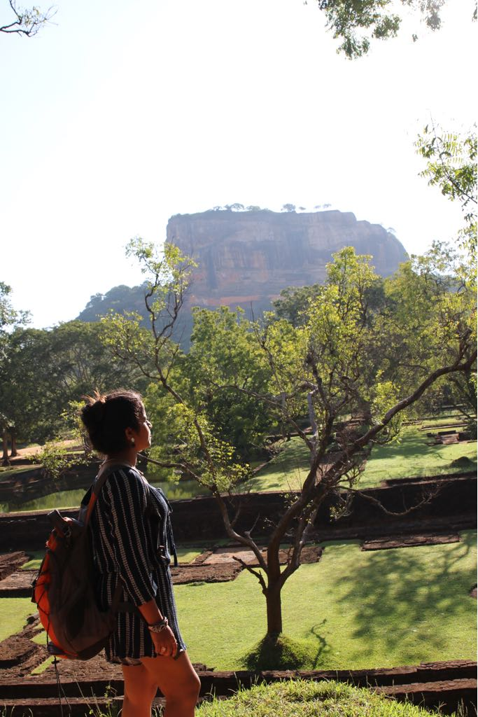

```r
library(tidyverse)
library(skimr)
```

```r
thanksgiving <- read.csv('https://raw.githubusercontent.com/rfordatascience/tidytuesday/master/data/2018/2018-11-20/thanksgiving_meals.csv')
```

### Part 2: Data Wrangling and visualization

###1. Display the first 10 rows of the dataset using RMarkdown (1 marks)

###install package

```r
###install.packages("kableExtra")
library(kableExtra)
###install.packages("janitor")

library(janitor)
library(tidyverse)
library(datarium)
```

```r
thanksgiving %>%
  head(10) %>%
  kbl()
```

| id | celebrate | main_dish | main_dish_other | main_prep | main_prep_other | stuffing | stuffing_other | cranberry | cranberry_other | gravy | side1 | side2 | side3 | side4 | side5 | side6 | side7 | side8 | side9 | side10 | side11 | side12 | side13 | side14 | side15 | pie1 | pie2 | pie3 | pie4 | … |
| --- | --- | --- | --- | --- | --- | --- | --- | --- | --- | --- | --- | --- | --- | --- | --- | --- | --- | --- | --- | --- | --- | --- | --- | --- | --- | --- | --- | --- | --- | --- |
| 4337954960 | Yes | Turkey | NA | Baked | NA | Bread-based | NA | None | NA | Yes | NA | Carrots | NA | NA | NA | NA | Green beans/green bean casserole | Macaroni and cheese | Mashed potatoes | NA | NA | NA | Yams/sweet potato casserole | NA | NA | Apple | NA | NA | NA | … |
| 4337951949 | Yes | Turkey | NA | Baked | NA | Bread-based | NA | Other (please specify) | Homemade cranberry gelatin ring | Yes | NA | NA | NA | Corn | NA | NA | Green beans/green bean casserole | Macaroni and cheese | Mashed potatoes | Rolls/biscuits | NA | Vegetable salad | Yams/sweet potato casserole | Other (please specify) | Asian vinagrette salad | Apple | NA | NA | Chocolate | … |
| 4337935621 | Yes | Turkey | NA | Roasted | NA | Rice-based | NA | Homemade | NA | Yes | Brussel sprouts | Carrots | Cauliflower | Corn | Cornbread | NA | NA | NA | Mashed potatoes | Rolls/biscuits | NA | Vegetable salad | NA | NA | NA | Apple | NA | Cherry | NA | … |
| 4337933040 | Yes | Turkey | NA | Baked | NA | Bread-based | NA | Homemade | NA | Yes | Brussel sprouts | NA | NA | NA | Cornbread | NA | NA | NA | Mashed potatoes | Rolls/biscuits | NA | Vegetable salad | Yams/sweet potato casserole | NA | NA | NA | NA | NA | NA | … |
| 4337931983 | Yes | Tofurkey | NA | Baked | NA | Bread-based | NA | Canned | NA | Yes | Brussel sprouts | NA | NA | NA | Cornbread | NA | NA | NA | Mashed potatoes | Rolls/biscuits | Squash | Vegetable salad | Yams/sweet potato casserole | NA | NA | Apple | NA | NA | NA | … |
| 4337929779 | Yes | Turkey | NA | Roasted | NA | Rice-based | NA | Homemade | NA | Yes | Brussel sprouts | Carrots | Cauliflower | Corn | Cornbread | Fruit salad | Green beans/green bean casserole | Macaroni and cheese | Mashed potatoes | Rolls/biscuits | Squash | Vegetable salad | Yams/sweet potato casserole | NA | NA | NA | NA | NA | NA | … |
| 4337924420 | Yes | Turkey | NA | Baked | NA | Bread-based | NA | Canned | NA | Yes | NA | NA | NA | NA | NA | Fruit salad | Green beans/green bean casserole | NA | Mashed potatoes | Rolls/biscuits | NA | NA | Yams/sweet potato casserole | NA | NA | Apple | NA | NA | NA | … |
| 4337916002 | Yes | Turkey | NA | Baked | NA | Rice-based | NA | Homemade | NA | Yes | NA | Carrots | NA | NA | NA | NA | NA | NA | NA | NA | NA | NA | NA | NA | NA | NA | NA | NA | Chocolate | … |
| 4337914977 | Yes | Turkey | NA | Roasted | NA | Bread-based | NA | Canned | NA | Yes | Brussel sprouts | NA | NA | Corn | Cornbread | NA | Green beans/green bean casserole | NA | Mashed potatoes | Rolls/biscuits | Squash | NA | NA | NA | NA | Apple | Buttermilk | NA | NA | … |
| 4337899817 | Yes | Other (please specify) | Turkey and Ham | Baked | NA | Bread-based | NA | Other (please specify) | Both Canned and Homemade | Yes | Brussel sprouts | Carrots | NA | NA | NA | NA | Green beans/green bean casserole | NA | Mashed potatoes | Rolls/biscuits | NA | NA | Yams/sweet potato casserole | NA | NA | NA | Buttermilk | NA | NA | … |

###2. Use `fct_reorder` and `parse_number` functions to create a factor variable `family_income`

```r
#thanksgiving<-thanksgiving%>%
#mutate(family_income=parse_number(family_income))%>%
#mutate(family_income=as_factor(family_income))

#class(thanksgiving$family_income)
#levels(thanksgiving$family_income)
#income_level<-c("0", "10000", "25000", "50000", "75000", "100000", "125000", "150000", "175000", "200000")
thanksgiving%>%
mutate(family_level=fct_reorder(family_income,parse_number(family_income)))
```

[output not shown]

[output cut: 22224 more lines]

```r
class(thanksgiving$family_income)
```

```
## [1] "character"
```

###3. Generate the general statistics of the dataset using `summary()` and `skim()` function (2 mark).

```r
summary(thanksgiving)%>%
  kbl(align = "c", caption = "summary")%>%
  kable_styling(bootstrap_options = "striped")
```

summary

|  | id | celebrate | main_dish | main_dish_other | main_prep | main_prep_other | stuffing | stuffing_other | cranberry | cranberry_other | gravy | side1 | side2 | side3 | side4 | side5 | side6 | side7 | side8 | side9 | side10 | side11 | side12 | side13 | side14 | side15 | pie1 | pie2 | pie3 | … |
| --- | --- | --- | --- | --- | --- | --- | --- | --- | --- | --- | --- | --- | --- | --- | --- | --- | --- | --- | --- | --- | --- | --- | --- | --- | --- | --- | --- | --- | --- | --- |
|  | Min. :4.336e+09 | Length:1058 | Length:1058 | Length:1058 | Length:1058 | Length:1058 | Length:1058 | Length:1058 | Length:1058 | Length:1058 | Length:1058 | Length:1058 | Length:1058 | Length:1058 | Length:1058 | Length:1058 | Length:1058 | Length:1058 | Length:1058 | Length:1058 | Length:1058 | Length:1058 | Length:1058 | Length:1058 | Length:1058 | Length:1058 | Length:1058 | Length:1058 | Length:1058 | … |
|  | 1st Qu.:4.336e+09 | Class :character | Class :character | Class :character | Class :character | Class :character | Class :character | Class :character | Class :character | Class :character | Class :character | Class :character | Class :character | Class :character | Class :character | Class :character | Class :character | Class :character | Class :character | Class :character | Class :character | Class :character | Class :character | Class :character | Class :character | Class :character | Class :character | Class :character | Class :character | … |
|  | Median :4.337e+09 | Mode :character | Mode :character | Mode :character | Mode :character | Mode :character | Mode :character | Mode :character | Mode :character | Mode :character | Mode :character | Mode :character | Mode :character | Mode :character | Mode :character | Mode :character | Mode :character | Mode :character | Mode :character | Mode :character | Mode :character | Mode :character | Mode :character | Mode :character | Mode :character | Mode :character | Mode :character | Mode :character | Mode :character | … |
|  | Mean :4.337e+09 | NA | NA | NA | NA | NA | NA | NA | NA | NA | NA | NA | NA | NA | NA | NA | NA | NA | NA | NA | NA | NA | NA | NA | NA | NA | NA | NA | NA | … |
|  | 3rd Qu.:4.337e+09 | NA | NA | NA | NA | NA | NA | NA | NA | NA | NA | NA | NA | NA | NA | NA | NA | NA | NA | NA | NA | NA | NA | NA | NA | NA | NA | NA | NA | … |
|  | Max. :4.338e+09 | NA | NA | NA | NA | NA | NA | NA | NA | NA | NA | NA | NA | NA | NA | NA | NA | NA | NA | NA | NA | NA | NA | NA | NA | NA | NA | NA | NA | … |

```r
skim(thanksgiving)%>%
  kbl(align = "c", caption = "skim")%>%
  kable_styling(bootstrap_options = "striped")
```

skim

| skim_type | skim_variable | n_missing | complete_rate | character.min | character.max | character.empty | character.n_unique | character.whitespace | numeric.mean | numeric.sd | numeric.p0 | numeric.p25 | numeric.p50 | numeric.p75 | numeric.p100 | numeric.hist |
| --- | --- | --- | --- | --- | --- | --- | --- | --- | --- | --- | --- | --- | --- | --- | --- | --- |
| character | celebrate | 0 | 1.0000000 | 2 | 3 | 0 | 2 | 0 | NA | NA | NA | NA | NA | NA | NA | NA |
| character | main_dish | 84 | 0.9206049 | 6 | 22 | 0 | 8 | 0 | NA | NA | NA | NA | NA | NA | NA | NA |
| character | main_dish_other | 1023 | 0.0330813 | 4 | 85 | 0 | 32 | 0 | NA | NA | NA | NA | NA | NA | NA | NA |
| character | main_prep | 84 | 0.9206049 | 5 | 22 | 0 | 5 | 0 | NA | NA | NA | NA | NA | NA | NA | NA |
| character | main_prep_other | 1007 | 0.0482042 | 1 | 33 | 0 | 32 | 0 | NA | NA | NA | NA | NA | NA | NA | NA |
| character | stuffing | 84 | 0.9206049 | 4 | 22 | 0 | 4 | 0 | NA | NA | NA | NA | NA | NA | NA | NA |
| character | stuffing_other | 1022 | 0.0340265 | 4 | 46 | 0 | 29 | 0 | NA | NA | NA | NA | NA | NA | NA | NA |
| character | cranberry | 84 | 0.9206049 | 4 | 22 | 0 | 4 | 0 | NA | NA | NA | NA | NA | NA | NA | NA |
| character | cranberry_other | 1033 | 0.0236295 | 3 | 61 | 0 | 24 | 0 | NA | NA | NA | NA | NA | NA | NA | NA |
| character | gravy | 84 | 0.9206049 | 2 | 3 | 0 | 2 | 0 | NA | NA | NA | NA | NA | NA | NA | NA |
| character | side1 | 903 | 0.1465028 | 15 | 15 | 0 | 1 | 0 | NA | NA | NA | NA | NA | NA | NA | NA |
| character | side2 | 816 | 0.2287335 | 7 | 7 | 0 | 1 | 0 | NA | NA | NA | NA | NA | NA | NA | NA |
| character | side3 | 970 | 0.0831758 | 11 | 11 | 0 | 1 | 0 | NA | NA | NA | NA | NA | NA | NA | NA |
| character | side4 | 594 | 0.4385633 | 4 | 4 | 0 | 1 | 0 | NA | NA | NA | NA | NA | NA | NA | NA |
| character | side5 | 823 | 0.2221172 | 9 | 9 | 0 | 1 | 0 | NA | NA | NA | NA | NA | NA | NA | NA |
| character | side6 | 843 | 0.2032136 | 11 | 11 | 0 | 1 | 0 | NA | NA | NA | NA | NA | NA | NA | NA |
| character | side7 | 372 | 0.6483932 | 32 | 32 | 0 | 1 | 0 | NA | NA | NA | NA | NA | NA | NA | NA |
| character | side8 | 852 | 0.1947070 | 19 | 19 | 0 | 1 | 0 | NA | NA | NA | NA | NA | NA | NA | NA |
| character | side9 | 241 | 0.7722117 | 15 | 15 | 0 | 1 | 0 | NA | NA | NA | NA | NA | NA | NA | NA |
| character | side10 | 292 | 0.7240076 | 14 | 14 | 0 | 1 | 0 | NA | NA | NA | NA | NA | NA | NA | NA |
| character | side11 | 887 | 0.1616257 | 6 | 6 | 0 | 1 | 0 | NA | NA | NA | NA | NA | NA | NA | NA |
| character | side12 | 849 | 0.1975425 | 15 | 15 | 0 | 1 | 0 | NA | NA | NA | NA | NA | NA | NA | NA |
| character | side13 | 427 | 0.5964083 | 27 | 27 | 0 | 1 | 0 | NA | NA | NA | NA | NA | NA | NA | NA |
| character | side14 | 947 | 0.1049149 | 22 | 22 | 0 | 1 | 0 | NA | NA | NA | NA | NA | NA | NA | NA |
| character | side15 | 947 | 0.1049149 | 4 | 78 | 0 | 89 | 0 | NA | NA | NA | NA | NA | NA | NA | NA |
| character | pie1 | 544 | 0.4858223 | 5 | 5 | 0 | 1 | 0 | NA | NA | NA | NA | NA | NA | NA | NA |
| character | pie2 | 1023 | 0.0330813 | 10 | 10 | 0 | 1 | 0 | NA | NA | NA | NA | NA | NA | NA | NA |
| character | pie3 | 945 | 0.1068053 | 6 | 6 | 0 | 1 | 0 | NA | NA | NA | NA | NA | NA | NA | NA |
| character | pie4 | 925 | 0.1257089 | 9 | 9 | 0 | 1 | 0 | NA | NA | NA | NA | NA | NA | NA | NA |
| character | pie5 | 1022 | 0.0340265 | 13 | 13 | 0 | 1 | 0 | NA | NA | NA | NA | NA | NA | NA | NA |
| character | pie6 | 1019 | 0.0368620 | 8 | 8 | 0 | 1 | 0 | NA | NA | NA | NA | NA | NA | NA | NA |
| character | pie7 | 1024 | 0.0321361 | 5 | 5 | 0 | 1 | 0 | NA | NA | NA | NA | NA | NA | NA | NA |
| character | pie8 | 716 | 0.3232514 | 5 | 5 | 0 | 1 | 0 | NA | NA | NA | NA | NA | NA | NA | NA |
| character | pie9 | 329 | 0.6890359 | 7 | 7 | 0 | 1 | 0 | NA | NA | NA | NA | NA | NA | NA | NA |
| character | pie10 | 906 | 0.1436673 | 12 | 12 | 0 | 1 | 0 | NA | NA | NA | NA | NA | NA | NA | NA |
| character | pie11 | 1018 | 0.0378072 | 4 | 4 | 0 | 1 | 0 | NA | NA | NA | NA | NA | NA | NA | NA |
| character | pie12 | 987 | 0.0671078 | 22 | 22 | 0 | 1 | 0 | NA | NA | NA | NA | NA | NA | NA | NA |
| character | pie13 | 987 | 0.0671078 | 5 | 46 | 0 | 61 | 0 | NA | NA | NA | NA | NA | NA | NA | NA |
| character | dessert1 | 948 | 0.1039698 | 13 | 13 | 0 | 1 | 0 | NA | NA | NA | NA | NA | NA | NA | NA |
| character | dessert2 | 1042 | 0.0151229 | 8 | 8 | 0 | 1 | 0 | NA | NA | NA | NA | NA | NA | NA | NA |
| character | dessert3 | 930 | 0.1209830 | 8 | 8 | 0 | 1 | 0 | NA | NA | NA | NA | NA | NA | NA | NA |
| character | dessert4 | 986 | 0.0680529 | 11 | 11 | 0 | 1 | 0 | NA | NA | NA | NA | NA | NA | NA | NA |
| character | dessert5 | 867 | 0.1805293 | 10 | 10 | 0 | 1 | 0 | NA | NA | NA | NA | NA | NA | NA | NA |
| character | dessert6 | 854 | 0.1928166 | 7 | 7 | 0 | 1 | 0 | NA | NA | NA | NA | NA | NA | NA | NA |
| character | dessert7 | 1015 | 0.0406427 | 5 | 5 | 0 | 1 | 0 | NA | NA | NA | NA | NA | NA | NA | NA |
| character | dessert8 | 792 | 0.2514178 | 9 | 9 | 0 | 1 | 0 | NA | NA | NA | NA | NA | NA | NA | NA |
| character | dessert9 | 955 | 0.0973535 | 13 | 13 | 0 | 1 | 0 | NA | NA | NA | NA | NA | NA | NA | NA |
| character | dessert10 | 763 | 0.2788280 | 4 | 4 | 0 | 1 | 0 | NA | NA | NA | NA | NA | NA | NA | NA |
| character | dessert11 | 924 | 0.1266541 | 22 | 22 | 0 | 1 | 0 | NA | NA | NA | NA | NA | NA | NA | NA |
| character | dessert12 | 924 | 0.1266541 | 3 | 59 | 0 | 92 | 0 | NA | NA | NA | NA | NA | NA | NA | NA |
| character | prayer | 99 | 0.9064272 | 2 | 3 | 0 | 2 | 0 | NA | NA | NA | NA | NA | NA | NA | NA |
| character | travel | 107 | 0.8988658 | 59 | 80 | 0 | 4 | 0 | NA | NA | NA | NA | NA | NA | NA | NA |
| character | watch_program | 556 | 0.4744802 | 13 | 13 | 0 | 1 | 0 | NA | NA | NA | NA | NA | NA | NA | NA |
| character | kids_table_age | 107 | 0.8988658 | 2 | 13 | 0 | 12 | 0 | NA | NA | NA | NA | NA | NA | NA | NA |
| character | hometown_friends | 107 | 0.8988658 | 2 | 3 | 0 | 2 | 0 | NA | NA | NA | NA | NA | NA | NA | NA |
| character | friendsgiving | 107 | 0.8988658 | 2 | 3 | 0 | 2 | 0 | NA | NA | NA | NA | NA | NA | NA | NA |
| character | black_friday | 107 | 0.8988658 | 2 | 3 | 0 | 2 | 0 | NA | NA | NA | NA | NA | NA | NA | NA |
| character | work_retail | 107 | 0.8988658 | 2 | 3 | 0 | 2 | 0 | NA | NA | NA | NA | NA | NA | NA | NA |
| character | work_black_friday | 988 | 0.0661626 | 2 | 13 | 0 | 3 | 0 | NA | NA | NA | NA | NA | NA | NA | NA |
| character | community_type | 110 | 0.8960302 | 5 | 8 | 0 | 3 | 0 | NA | NA | NA | NA | NA | NA | NA | NA |
| character | age | 33 | 0.9688091 | 3 | 7 | 0 | 4 | 0 | NA | NA | NA | NA | NA | NA | NA | NA |
| character | gender | 33 | 0.9688091 | 4 | 6 | 0 | 2 | 0 | NA | NA | NA | NA | NA | NA | NA | NA |
| character | family_income | 33 | 0.9688091 | 12 | 20 | 0 | 11 | 0 | NA | NA | NA | NA | NA | NA | NA | NA |
| character | us_region | 59 | 0.9442344 | 7 | 18 | 0 | 9 | 0 | NA | NA | NA | NA | NA | NA | NA | NA |
| numeric | id | 0 | 1.0000000 | NA | NA | NA | NA | NA | 4336731188 | 493783.4 | 4335894916 | 4336339486 | 4336796628 | 4337012140 | 4337954960 | ▅▃▇▂▂ |

###4. What is the number of people who celebrate?

```r
cel <-thanksgiving %>%
  group_by(celebrate)%>%
  summarise(Total=n())
kable(cel)
```

| celebrate | Total |
| --- | --- |
| No | 78 |
| Yes | 980 |

###5. What are categories and stats for each main dish served and the method it is prepared?

```r
kable(thanksgiving%>%
  count(main_dish, main_prep, sort = TRUE))
```

| main_dish | main_prep | n |
| --- | --- | --- |
| Turkey | Baked | 422 |
| Turkey | Roasted | 351 |
| NA | NA | 84 |
| Turkey | Fried | 41 |
| Turkey | Other (please specify) | 34 |
| Ham/Pork | Baked | 22 |
| Other (please specify) | Baked | 16 |
| Tofurkey | Baked | 14 |
| Other (please specify) | Other (please specify) | 12 |
| Turkey | I don’t know | 11 |
| Ham/Pork | Roasted | 5 |
| Other (please specify) | Roasted | 5 |
| Roast beef | Roasted | 5 |
| Chicken | Baked | 4 |
| Chicken | Roasted | 4 |
| Tofurkey | Roasted | 4 |
| I don’t know | I don’t know | 3 |
| Roast beef | Baked | 3 |
| Turducken | Roasted | 3 |
| Chicken | Fried | 2 |
| Chicken | Other (please specify) | 2 |
| Roast beef | Fried | 2 |
| Ham/Pork | I don’t know | 1 |
| Ham/Pork | Other (please specify) | 1 |
| I don’t know | Fried | 1 |
| I don’t know | Roasted | 1 |
| Other (please specify) | Fried | 1 |
| Other (please specify) | I don’t know | 1 |
| Roast beef | Other (please specify) | 1 |
| Tofurkey | I don’t know | 1 |
| Tofurkey | Other (please specify) | 1 |

###6. Create a data viz showing this in the most evident way. Provide your own legend and use themes.

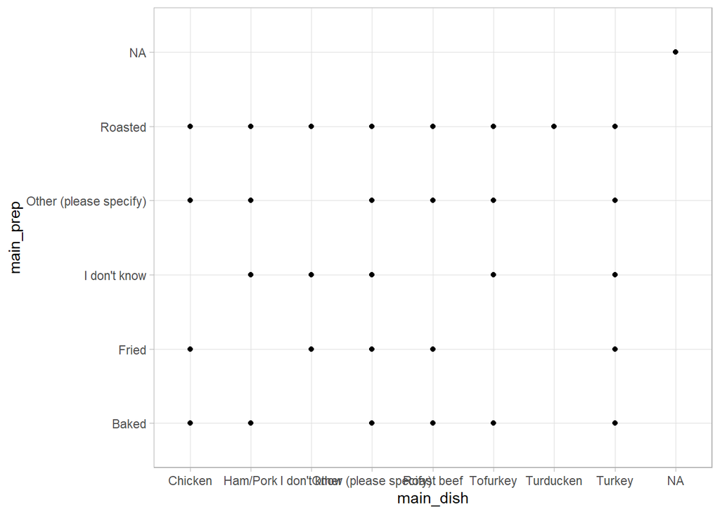

```r
library(datarium)
thanksgiving%>%ggplot(
  aes(
    x=main_dish,
    y=main_prep
  ))+
  geom_point()+
  theme_light()+
  guides(fill="colorbar")
```

###7. How many use cranberry sauce? How many use gravy?

```r
can<-thanksgiving%>%
  group_by(cranberry)%>%
  summarise(Total=n())
  kable(can)
```

| cranberry | Total |
| --- | --- |
| Canned | 502 |
| Homemade | 301 |
| None | 146 |
| Other (please specify) | 25 |
| NA | 84 |

```r
  grav<-thanksgiving%>%
    group_by(gravy)%>%
    summarise(Total=n())
    kable(grav)
```

| gravy | Total |
| --- | --- |
| No | 82 |
| Yes | 892 |
| NA | 84 |

###8. What is the distribution of those who celebrate across income ranges

```r
thanksgiving%>%
  count(family_income, celebrate, sort = FALSE)
```

```
##           family_income celebrate   n
## 1          $0 to $9,999        No  14
## 2          $0 to $9,999       Yes  52
## 3    $10,000 to $24,999        No   8
## 4    $10,000 to $24,999       Yes  60
## 5  $100,000 to $124,999        No   2
## 6  $100,000 to $124,999       Yes 109
## 7  $125,000 to $149,999        No   1
## 8  $125,000 to $149,999       Yes  48
## 9  $150,000 to $174,999        No   2
## 10 $150,000 to $174,999       Yes  38
## 11 $175,000 to $199,999        No   1
## 12 $175,000 to $199,999       Yes  26
## 13      $200,000 and up        No   4
## 14      $200,000 and up       Yes  76
## 15   $25,000 to $49,999        No  14
## 16   $25,000 to $49,999       Yes 166
## 17   $50,000 to $74,999        No   8
## 18   $50,000 to $74,999       Yes 127
## 19   $75,000 to $99,999        No   6
## 20   $75,000 to $99,999       Yes 127
## 21 Prefer not to answer        No  18
## 22 Prefer not to answer       Yes 118
## 23                 <NA>       Yes  33
```

###9. Present this information in the most evident way on the data viz.

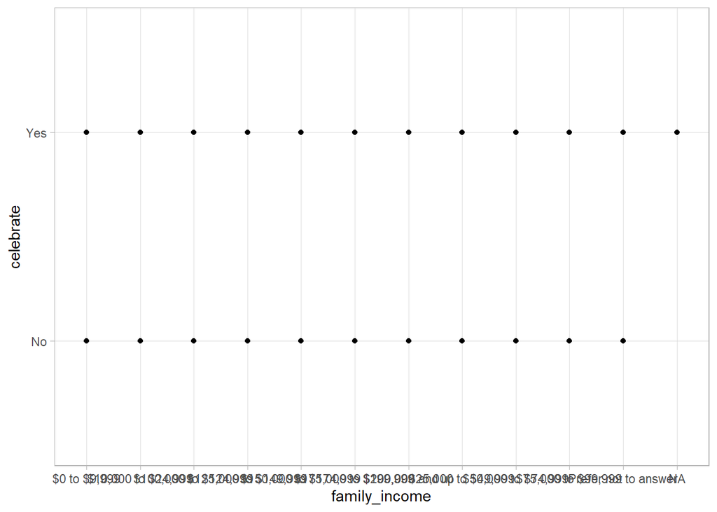

```r
library(datarium)
thanksgiving%>%ggplot(
  aes(
    x=family_income,
    y=celebrate
  ))+
  geom_point()+
  theme_light()+
  guides(fill="colorbar")
```

###10. What are the most common pies, sides, and desserts?

```r
piesidedessert<-thanksgiving%>%
select(starts_with("side"), starts_with("pie"), starts_with("dessert"))%>%
select(-side15, -pie13, -dessert12)%>%
gather(type, name)
piesidedessert%>%
count(type, name, sort=TRUE)
```

```
##         type                             name    n
## 1   dessert2                             <NA> 1042
## 2       pie7                             <NA> 1024
## 3       pie2                             <NA> 1023
## 4       pie5                             <NA> 1022
## 5       pie6                             <NA> 1019
## 6      pie11                             <NA> 1018
## 7   dessert7                             <NA> 1015
## 8      pie12                             <NA>  987
## 9   dessert4                             <NA>  986
## 10     side3                             <NA>  970
## 11  dessert9                             <NA>  955
## 12  dessert1                             <NA>  948
## 13    side14                             <NA>  947
## 14      pie3                             <NA>  945
```

[output cut: 60 more lines]

###13. How do the servings differ by income?

```r
kable(thanksgiving%>%
  count(family_income, main_dish, sort = TRUE))
```

| family_income | main_dish | n |
| --- | --- | --- |
| $25,000 to $49,999 | Turkey | 144 |
| $50,000 to $74,999 | Turkey | 118 |
| $75,000 to $99,999 | Turkey | 112 |
| Prefer not to answer | Turkey | 104 |
| $100,000 to $124,999 | Turkey | 99 |
| $200,000 and up | Turkey | 68 |
| $10,000 to $24,999 | Turkey | 47 |
| $0 to $9,999 | Turkey | 43 |
| $125,000 to $149,999 | Turkey | 43 |
| $150,000 to $174,999 | Turkey | 34 |
| NA | Turkey | 24 |
| $175,000 to $199,999 | Turkey | 23 |
| Prefer not to answer | NA | 18 |
| $0 to $9,999 | NA | 14 |
| $25,000 to $49,999 | NA | 14 |
| $10,000 to $24,999 | NA | 8 |
| $25,000 to $49,999 | Other (please specify) | 8 |
| $50,000 to $74,999 | NA | 8 |
| $75,000 to $99,999 | Ham/Pork | 8 |
| $25,000 to $49,999 | Ham/Pork | 6 |
| $75,000 to $99,999 | NA | 6 |
| NA | NA | 6 |
| $75,000 to $99,999 | Other (please specify) | 5 |
| $10,000 to $24,999 | Ham/Pork | 4 |
| $100,000 to $124,999 | Other (please specify) | 4 |
| $200,000 and up | NA | 4 |
| $25,000 to $49,999 | Tofurkey | 4 |
| Prefer not to answer | Other (please specify) | 4 |
| $0 to $9,999 | Roast beef | 3 |
| $10,000 to $24,999 | Chicken | 3 |
| $10,000 to $24,999 | Other (please specify) | 3 |
| $100,000 to $124,999 | Tofurkey | 3 |
| $25,000 to $49,999 | Chicken | 3 |
| $50,000 to $74,999 | Other (please specify) | 3 |
| Prefer not to answer | Tofurkey | 3 |
| $0 to $9,999 | Chicken | 2 |
| $0 to $9,999 | I don’t know | 2 |
| $10,000 to $24,999 | Tofurkey | 2 |
| $100,000 to $124,999 | Ham/Pork | 2 |
| $100,000 to $124,999 | NA | 2 |
| $125,000 to $149,999 | Other (please specify) | 2 |
| $125,000 to $149,999 | Tofurkey | 2 |
| $150,000 to $174,999 | Other (please specify) | 2 |
| $150,000 to $174,999 | NA | 2 |
| $175,000 to $199,999 | Other (please specify) | 2 |
| $200,000 and up | Ham/Pork | 2 |
| $200,000 and up | Other (please specify) | 2 |
| $200,000 and up | Turducken | 2 |
| $50,000 to $74,999 | Ham/Pork | 2 |
| $50,000 to $74,999 | Roast beef | 2 |
| $75,000 to $99,999 | Tofurkey | 2 |
| Prefer not to answer | Chicken | 2 |
| Prefer not to answer | Roast beef | 2 |
| $0 to $9,999 | Ham/Pork | 1 |
| $0 to $9,999 | Tofurkey | 1 |
| $10,000 to $24,999 | Roast beef | 1 |
| $100,000 to $124,999 | Chicken | 1 |
| $125,000 to $149,999 | Ham/Pork | 1 |
| $125,000 to $149,999 | NA | 1 |
| $150,000 to $174,999 | Ham/Pork | 1 |
| $150,000 to $174,999 | Roast beef | 1 |
| $175,000 to $199,999 | Tofurkey | 1 |
| $175,000 to $199,999 | NA | 1 |
| $200,000 and up | Chicken | 1 |
| $200,000 and up | Tofurkey | 1 |
| $25,000 to $49,999 | Roast beef | 1 |
| $50,000 to $74,999 | I don’t know | 1 |
| $50,000 to $74,999 | Tofurkey | 1 |
| Prefer not to answer | Ham/Pork | 1 |
| Prefer not to answer | I don’t know | 1 |
| Prefer not to answer | Turducken | 1 |
| NA | Ham/Pork | 1 |
| NA | I don’t know | 1 |
| NA | Roast beef | 1 |

```r
kable(thanksgiving%>%
        count(family_income, side1, sort=TRUE))
```

| family_income | side1 | n |
| --- | --- | --- |
| $25,000 to $49,999 | NA | 164 |
| $50,000 to $74,999 | NA | 121 |
| Prefer not to answer | NA | 115 |
| $75,000 to $99,999 | NA | 108 |
| $100,000 to $124,999 | NA | 91 |
| $10,000 to $24,999 | NA | 61 |
| $0 to $9,999 | NA | 59 |
| $200,000 and up | NA | 58 |
| $125,000 to $149,999 | NA | 42 |
| $150,000 to $174,999 | NA | 33 |
| NA | NA | 31 |
| $75,000 to $99,999 | Brussel sprouts | 25 |
| $200,000 and up | Brussel sprouts | 22 |
| Prefer not to answer | Brussel sprouts | 21 |
| $100,000 to $124,999 | Brussel sprouts | 20 |
| $175,000 to $199,999 | NA | 20 |
| $25,000 to $49,999 | Brussel sprouts | 16 |
| $50,000 to $74,999 | Brussel sprouts | 14 |
| $0 to $9,999 | Brussel sprouts | 7 |
| $10,000 to $24,999 | Brussel sprouts | 7 |
| $125,000 to $149,999 | Brussel sprouts | 7 |
| $150,000 to $174,999 | Brussel sprouts | 7 |
| $175,000 to $199,999 | Brussel sprouts | 7 |
| NA | Brussel sprouts | 2 |

```r
kable(thanksgiving%>%
        count(family_income, dessert1, sort=TRUE))
```

| family_income | dessert1 | n |
| --- | --- | --- |
| $25,000 to $49,999 | NA | 161 |
| $50,000 to $74,999 | NA | 123 |
| Prefer not to answer | NA | 121 |
| $75,000 to $99,999 | NA | 118 |
| $100,000 to $124,999 | NA | 102 |
| $200,000 and up | NA | 74 |
| $0 to $9,999 | NA | 56 |
| $10,000 to $24,999 | NA | 52 |
| $125,000 to $149,999 | NA | 46 |
| $150,000 to $174,999 | NA | 38 |
| NA | NA | 32 |
| $175,000 to $199,999 | NA | 25 |
| $25,000 to $49,999 | Apple cobbler | 19 |
| $10,000 to $24,999 | Apple cobbler | 16 |
| $75,000 to $99,999 | Apple cobbler | 15 |
| Prefer not to answer | Apple cobbler | 15 |
| $50,000 to $74,999 | Apple cobbler | 12 |
| $0 to $9,999 | Apple cobbler | 10 |
| $100,000 to $124,999 | Apple cobbler | 9 |
| $200,000 and up | Apple cobbler | 6 |
| $125,000 to $149,999 | Apple cobbler | 3 |
| $150,000 to $174,999 | Apple cobbler | 2 |
| $175,000 to $199,999 | Apple cobbler | 2 |
| NA | Apple cobbler | 1 |

14. Present this information on a data viz

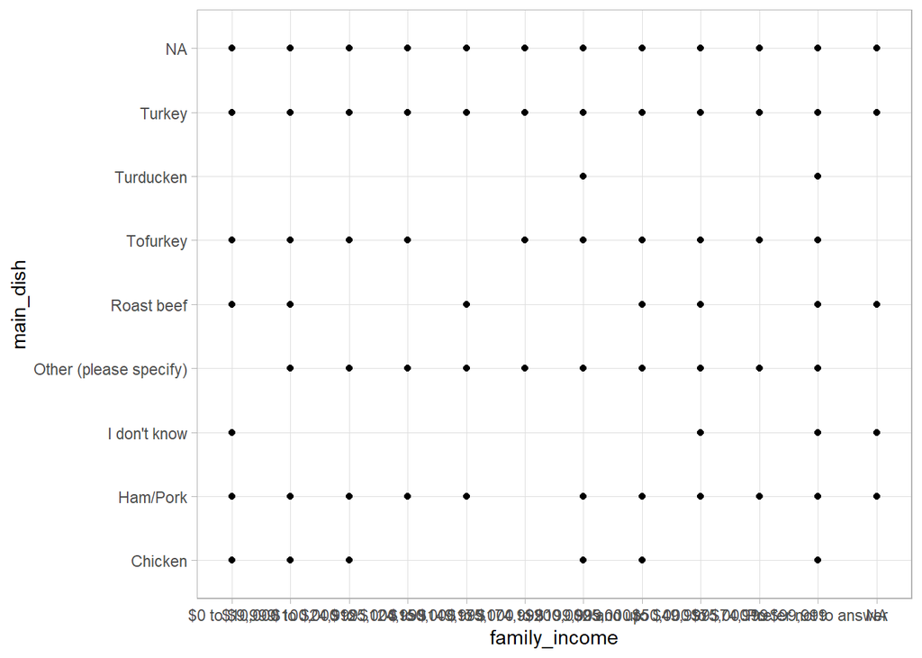

```r
library(datarium)
thanksgiving%>%ggplot(
  aes(
    x=family_income,
    y=main_dish
  ))+
  geom_point()+
  theme_light()+
  guides(fill="colorbar")
```

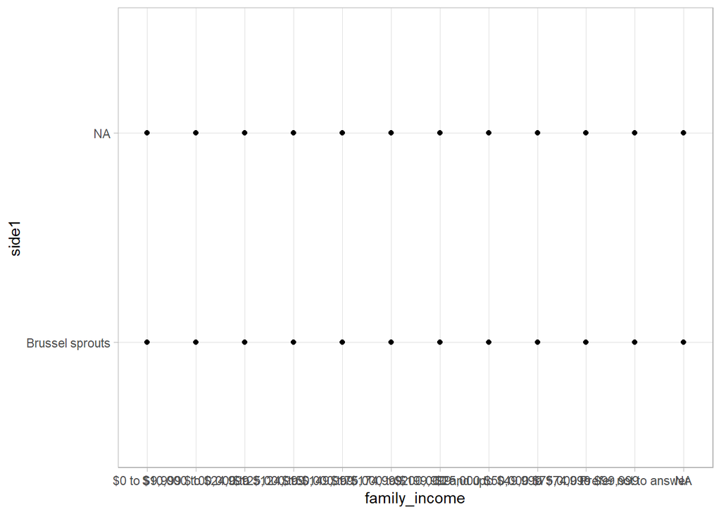

```r
thanksgiving%>%ggplot(
  aes(
    x=family_income,
    y=side1
  ))+
  geom_point()+
  theme_light()+
  guides(fill="colorbar")
```

#### Resources:

RMarkdown tutorial https://rmarkdown.rstudio.com/lesson-1.html

ggplot2: Elegant Graphics for Data Analysis https://ggplot2-book.org